# Vectors, Data Frames, and Functions

## Functions are your friends

While basic operations, such as addition, are invaluable features of R, the real core of R comes in the form of functions. Functions, in general, take arguments and convert them into output. That output can be a detailed statistical test, a chart or graph, or a simple summation – the important thing to realize is that fundamentally all functions in R obey similar rules. A function in R is anything that can be specified by a name with a set of parentheses after it – containing the function’s arguments. Arguments are the input a function needs to perform its task and produce the desired output.

This will become slightly clearer when I discuss the help utility below, but arguments can either be required or they can take on default values if unspecified. Because it would be tricky to keep track of the order of 10 possible inputs, which all might be optional, R allows the naming of these arguments in the function. This makes R functions easy to write and read, after a bit of acclimation.

Take the log() function. It has one required argument, the number for which you want the logarithm, obviously. But it also has one optional argument, base. This argument defaults to e if omitted.

So, you can determine the natural log of something quite easily, as in,

`r log(10)`

`## [1] 2.302585`

To get the log base-10 of 10, you can write either

`r log(10, 10)`

`## [1] 1`

`r log(10, base=10)`

`## [1] 1`

“So, why would I ever want to do the second option?” you ask. Here, it would not much matter. It would be slightly easier to understand what is going on to a reader of your code in the second case, but maybe not enough useful to justify the extra typing.

But as we move to more complex functions, especially the graphic functions like plot, the number of potential arguments is huge. Do you want a sub-caption for the y-axis? Most likely not, but when you do need one it is very valuable argument to have waiting in the wings. In those functions, the first couple of arguments will be specified without a name and then the rest will look like the base=10 argument above. For example, almost every plot you produce will need a label on the x-axis, say, so you will find yourself typing xlab= a lot.

## Getting help

When you do not know what a function does or what arguments is takes, R’s in-line help system is exceptionally handy. The easiest way to access help on a specific function, such as log, is

`r ?log`

But equivalently, you can type

`r help(log)`

When the item you need help on is an operator, rather than a standard function (like the addition operator, +) only the second of these will work, and you must include the operator in quotes, as in

`r help("+")`

Help files in R can seem intimidating. The trick is to know what you don’t need to know. Often you will end up using only a few of the arguments. Most arguments will have standard, acceptable defaults noted by something like name=FALSE. You do not need to understand every argument in a function to get it to do what you want.

The descriptions can be helpful, but you’ll also want to look at the examples. The examples tend to be targeted at common scenarios and are most often well framed.

Lastly, the “see also” section may be useful if you are looking for a function but only know the name of a similar function.

Conversely, you might know what a function does, but not know R’s name for it. There is no incredibly satisfactory solution to this, but a good first step is to search within the in-line help documentation for the concept:

`r help.search("average")`

Or, equivalently,

`r ??average`

The next step is to search the R website, http://www.r-project.org, for any help it can provide. The easiest way to do this from within R is to type

`r RSiteSearch("average")`

`## A search query has been submitted to http://search.r-project.org ## The results page should open in your browser shortly`

With these tools in hand, you should be ready to troubleshoot most of your R foibles yourself!

## Introduction to Vectors

### What is a vector?

Statisticians worry about multiple numbers, not single numbers like we have seen so far. So it is not surprising that most of the computation you will perform in R will involve more complex data structures.

The simplest such structure is the vector, which is nothing more than a list of numbers, stored in the same place. All the rules you learned about assignment, above, still apply here, but there are some complications.

### Inputting your own vector

In order to generate vectors of any length, R has a somewhat non-intuitive method, the function c(). The name “c” is short for concatenate, if that helps you remember its very important role in R. The function takes any number of arguments, which have values of numbers or vectors. Some examples:

```r
my.vector <- c(1,2,3)
x <- 5
y <- 10
my.other.vector <- c(x,y)

my.last.vector <- c(my.vector, 365, my.other.vector)
```

It is pretty straightforward, once you get the hang of it.

### Generating Sequences

There are many occasions in R when you need a patterned sequence of numbers. As mentioned last in the last tutorial, most counting can be accomplished by use of the seq() function. If you haven’t already done so, it is worth taking a look at the help-file on seq() because it has a few arguments that can make your life easier.

```r
?seq
```

For example, seq() can generate a vector of a certain length between certain endpoints by typing

```r
x <- seq(0,1,length.out=20)
```

giving you a vector of length 20 between 0 and 1, confirmable by typing

```r
length(x)
```

```
## [1] 20
```

A very common need in R is to generate vectors with an interval of 1 between each element. R has a shorthand for this using the colon notation, as follows,

```r
y <- 5:10
```

### Element-wise vector operations

We can perfom elementwise operations with vectors as in the operations below

```r
x <- 1:6
2*x
```

```
## [1]  2  4  6  8 10 12
```

```r
y <- 1:5
z <- 6:10
y+z
```

```
## [1]  7  9 11 13 15
```

```r
y*z
```

```
## [1]  6 14 24 36 50
```

### Indexing vectors

R has an incredibly useful way of accessing items from a dataset. Each item in a dataset has its own index, or numbered location, in the object’s structure. Square brackets are used to extract an item or items from a dataset, but it is crucial to understand that there are two completely distinct ways in which brackets are used to access items. I will consider the two methods for accessing a vector of length n in turn below.

The first option: Logical

Requirements: Logical vector of length n Use it for: Finding a subset of data based on a rule

Logical indexing works as if you’ve asked your indexing vector the question, “Do you want this item?” for each of the items in the vector.

```r
x <- 1:5

x[c(T,F,F,F,T)]
```

```
## [1] 1 5
```

If we combine this logical indexing with the relational and logical operators you learned above, we have an exceptionally powerful tool to retrieve data that meet any set of criteria.

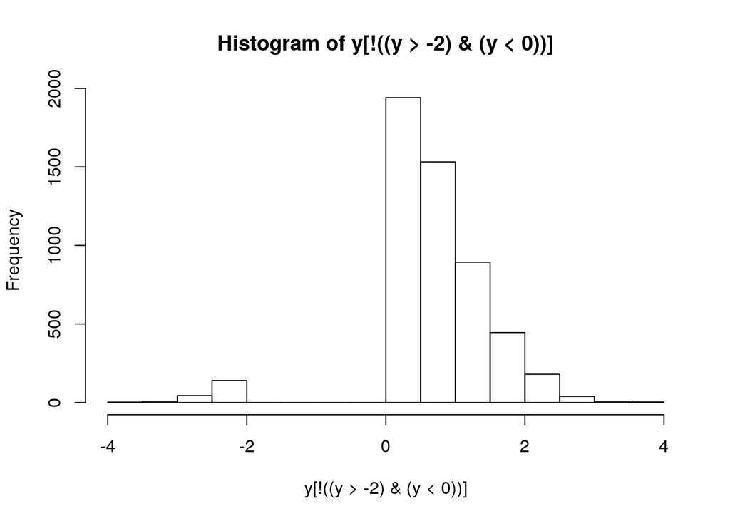

```r
y<-rnorm(10000)

hist(y[!((y>-2)&(y<0))])
```

I will give more insight below when I discuss indexing data frames. Stay tuned.

In any operation in R, vectors will be automatically repeated until they reach the necessary length for the operation to make sense. For example, note the results of

```r
1:6 + 1:2
```

```
## [1] 2 4 4 6 6 8
```

The same repetition holds for logical vectors.

The second option: Numerical

Requirements: Value or vector of any length with values (1 to n) OR (-n to -1) Use it for: Single item retrieval or shuffling, sorting, and repeating

Accessing single items with brackets and a single index should be straightforward

```r
x <- 3*(0:5)

x[4]
```

```
## [1] 9
```

One tedious way of creating a new vector of values from a vector’s elements would be

```r
c(x[2],x[3],x[4]) #TEDIOUS
```

```
## [1] 3 6 9
```

So R makes it much easier by allowing a vector of indices to generate a vector. Thereby, the command above becomes

```r
x[2:4]
```

```
## [1] 3 6 9
```

There is nothing preventing you from accessing any element any number of times.

```r
x[c(2,2,2,5,5,5)]
```

```
## [1]  3  3  3 12 12 12
```

Additionally, R allows you to use negative indices, indicating which items you want to exclude, as in,

```r
x[c(-1,-6)]
```

```
## [1]  3  6  9 12
```

### Sorting vectors

In Tutorial 1, you were introduced to the sort() function, which is handy.

Now that you have been introduced to indexing, you may have an inkling of how much more powerful the sorting functions of R can become.

As an introduction, let’s say you have a 4-element vector,

```r
my.vector <- 5:8
```

Using numerical indexing, we can manually re-order this vector by calling each of its indices once in our preferred order, for example

```r
my.vector[c(2,3,4,1)]
```

```
## [1] 6 7 8 5
```

or, for a quick reversal

```r
my.vector[4:1]
```

```
## [1] 8 7 6 5
```

Now, manually generating the vector of indices is not monumentally useful, which is where the function order() comes in. As demonstration, imagine we have a vector of student names and a corresponding vector of student heights (in meters).

```r
stud.names <- c("Carol", "Walter", "Rachael", "Petunia", "Clark",
                "Justin")

stud.heights <- rnorm(6,1.7,.12)
```

What we definitely don’t want to do is to perform sort() on each of these vectors independently. This will eliminate the pairing of the name to the height. So how can we sort one vector and have the other vector align correctly? Try order() on the names,

```r
order(stud.names)
```

```
## [1] 1 5 6 4 3 2
```

Note that it returns the indices in the right order, not the values themselves.

From what you learned above, you know it is now an easy matter to sort both of our vectors, as follows,

```r
stud.names[order(stud.names)] #same effect as sort()
```

```
## [1] "Carol"   "Clark"   "Justin"  "Petunia" "Rachael" "Walter"
```

```r
stud.heights[order(stud.names)]
```

```
## [1] 1.763509 1.784250 1.801126 1.817691 1.841029 1.716516
```

And, obviously, sorting the names by the heights is exactly analogous, and it will make for a pretty plot

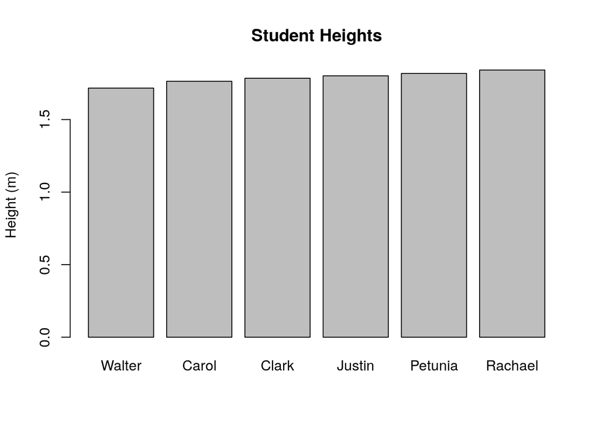

```r
barplot(stud.heights[order(stud.heights)],
        names.arg=stud.names[order(stud.heights)],
        ylab="Height (m)", main=
          "Student Heights")
```

I have conveniently skipped over an important concept, because R handles it fairly intuitively, but I want to mention the terminology. The variable stud.names and the results of ls(), for example, are called vectors of strings or character arrays.” R handles them conveniently, so we don’t need to worry too much about them, but knowing the terminology will improve your understanding of R’s in-line help documents.

## Data Frames

Re-introduction to data frames

Before we cover advanced topics of data frames, I wanted to point out the function data.frame() which puts data together to form data frames. This is a key alternative to using the prefab data frames that you used in last week’s assignment.

First I want to generate a vector of student class-years to correspond to the stud.names before creating a data frame (Freshmen as 1, Sophomores as 2, etc.).

```r
stud.years <- c(4,2,2,3,1,3)
```

Now making a data frame is easy (each argument will just add more columns to the data), the only trick being that we have to assign the constructed data frame to a variable, as follows,

```r
student.data <- data.frame(stud.heights,stud.years)

student.data
```

```
##   stud.heights stud.years
## 1     1.763509          4
## 2     1.716516          2
## 3     1.841029          2
## 4     1.817691          3
## 5     1.784250          1
## 6     1.801126          3
```

Voila! Your own data frame. But, wait, where are our the student names? And can we have better column headings than our redundant variable names?

The answers lie in two new functions that we will use with assignment notation, names() and row.names(). Let’s take a look:

```r
names(student.data)
```

```
## [1] "stud.heights" "stud.years"
```

```r
row.names(student.data)
```

```
## [1] "1" "2" "3" "4" "5" "6"
```

What we see are vectors of strings corresponding to the columns and rows, respectively. We can change these by assigning replacement strings to the indexed values or by substituting our own vector of strings.

```r
names(student.data)[1] <- "heights"

names(student.data)[2] <- "class.years"

row.names(student.data) <- stud.names
```

The result is downright beautiful:

```r
student.data
```

```
##          heights class.years
## Carol   1.763509           4
## Walter  1.716516           2
## Rachael 1.841029           2
## Petunia 1.817691           3
## Clark   1.784250           1
## Justin  1.801126           3
```

Indexing data frames

As with vectors, brackets and logical or numerical vectors are still the way to access data frames, but with a slight complication, because data frames are multidimensional. The solution (which also holds for matrices, etc.) is to separate the two dimensions with a comma. R treats the first entry as the row number and the second entry as the column number; thus, to access the second column of the fourth row, type

```r
student.data[4,2]
```

```
## [1] 3
```

Or the second column of the last three rows,

```r
student.data[4:6,2]
```

```
## [1] 3 1 3
```

Not too tricky? There are two further complications.

To access an entire row or entire column, leave the index blank, as in,

```r
student.data[,1] #FIRST COLUMN
```

```
## [1] 1.763509 1.716516 1.841029 1.817691 1.784250 1.801126
```

```r
student.data[3,] #THIRD ROW
```

```
##          heights class.years
## Rachael 1.841029           2
```

```r
student.data[,] #ENTIRE FRAME, equivalent to "student.data"
```

```
##          heights class.years
## Carol   1.763509           4
## Walter  1.716516           2
## Rachael 1.841029           2
## Petunia 1.817691           3
## Clark   1.784250           1
## Justin  1.801126           3
```

The only other complication is the ability to enter the names() or row.names() as indices:

```r
student.data["Justin",]
```

```
##         heights class.years
## Justin 1.801126           3
```

Putting all of this together, we can quickly generate subsets of our data:

```r
tall.students <- student.data[student.data$height >
                                mean(student.data$height),]
```

Or sort our data by various aspects:

```r
student.data[order(student.data$class.years),]
```

```
##          heights class.years
## Clark   1.784250           1
## Walter  1.716516           2
## Rachael 1.841029           2
## Petunia 1.817691           3
## Justin  1.801126           3
## Carol   1.763509           4
```